# Making A Movie Popular

Qian Zhu

2019/1/2

## Setup

### Load packages

```r
library(ggplot2)
library(dplyr)
library(statsr)
library(GGally)
```

## Making a Movie Popular

Thousands of movies are released every year, yet not all are welcomed by audiences. Numerous variables may affect the popularity of movies.

In this project, we are going to find out the attributes of making a movie popular, and try to predict a movie using a multiple linear regression model that will be developed later.

### Load data

```r
load("/Rachel/Study/Linear Regression and Modeling/Week 4/Movie Data.Rdata")
```

## Part 1: Data

The original data were gathered from 651 randomly sampled movies produced and released before 2016. 32 different variables were contained in the dataset,including numerical and categorical ones, as well as information from Rotten Tomatoes and IMDB for reference.

The data can be generalized to all US movies because of the randomly selection of the data. And no causality can be inferred.

Not all variables will be used in the project, since some of them are only for informational purposes and do not make any sense to reach a statistical result.

Therefore, we create a new dataset (movies_new) based on the original one, through selecting and combining some variables.

```r
movies_new <- movies[c(1:3,6,18,4,13,16,5,15,17,19:26)]
```

```r
movies_new
```

```
## # A tibble: 651 x 19
##    title title_type genre studio audience_score runtime imdb_rating
##    <chr> <fct>      <fct> <fct>           <dbl>   <dbl>       <dbl>
##  1 Fill… Feature F… Drama Indom…             73      80         5.5
##  2 The … Feature F… Drama Warne…             81     101         7.3
##  3 Wait… Feature F… Come… Sony …             91      84         7.6
##  4 The … Feature F… Drama Colum…             76     139         7.2
##  5 Male… Feature F… Horr… Ancho…             27      90         5.1
##  6 Old … Documenta… Docu… Shcal…             86      78         7.8
##  7 Lady… Feature F… Drama Param…             76     142         7.2
##  8 Mad … Feature F… Drama MGM/U…             47      93         5.5
##  9 Beau… Documenta… Docu… Indep…             89      88         7.5
## 10 The … Feature F… Drama IFC F…             66     119         6.6
## # ... with 641 more rows, and 12 more variables: critics_score <dbl>,
## #   mpaa_rating <fct>, critics_rating <fct>, audience_rating <fct>,
## #   best_pic_nom <fct>, best_pic_win <fct>, best_actor_win <fct>,
## #   best_actress_win <fct>, best_dir_win <fct>, top200_box <fct>,
## #   director <chr>, actor1 <chr>
```

## Part 2: Research question

Analysing the collected data, it is interesting to see whether `imdb_rating` and `critics_score` do affect popularity of a movie, and visualize the relationships with multiple linear regression model between `audience_score` and `imdb-rating` & `critics_score`. We also want to see what other categorical variables may affect the result. We may hopefully use the model to predict the popularity of new movies.

## Part 3: Exploratory data analysis

Since we already had dataset in hand, we will do exploratory data analysis (EDA) in this part.

Firstly, we will see the relationships between `audience_score` and `imdb_rating` & `critics_score`:

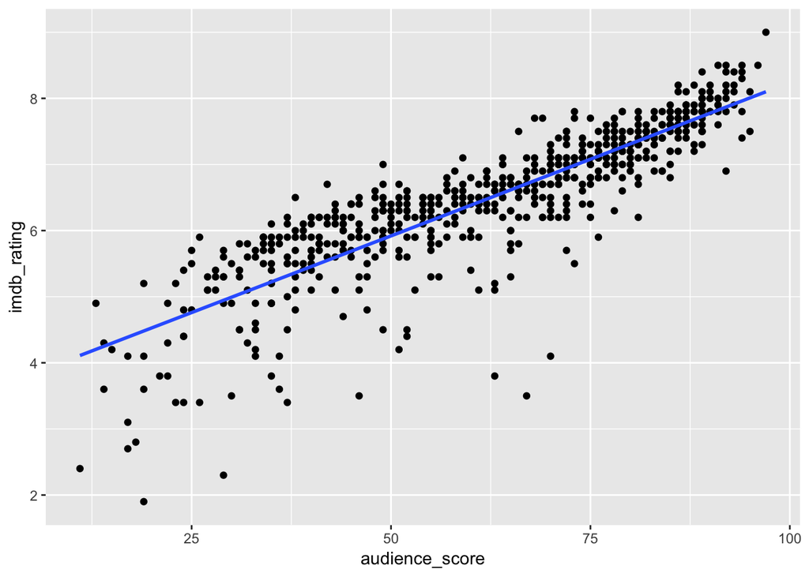

```r
ggplot(data = movies_new, aes(x = audience_score, y = imdb_rating)) +
  geom_point() +
  stat_smooth(method = "lm", se = FALSE)
```

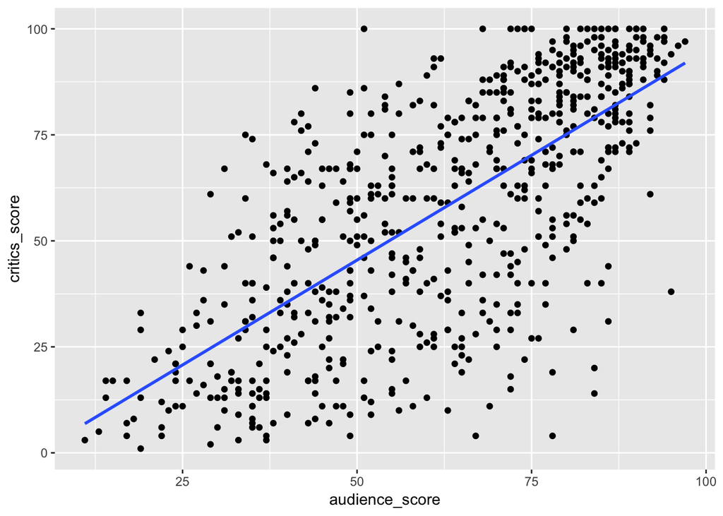

```r
ggplot(data = movies_new, aes(x = audience_score, y = critics_score)) +
  geom_point() +
  stat_smooth(method = "lm", se = FALSE)
```

It looks like that `audience_score` has strong relationships with `imdb_rating` and `critics_score`.

We will check the reliability of our hypotheses in the next part as well as the relationships between `audience_score` and categorial variables.

## Part 4: Modeling

Compared with the original (movies) and the new (movies_new) dataset we created before, we have excluded some variables such as `thtr_rel_month`, `thtr_rel_day`, `dvd_rel_month`, `dvd_rel_day`. `Actor2`, `actor3`, `actor4` and `actor5` are also omitted as it is meaningless to have so many levels of actor. `Imdb_url` and `rt_url` only provide information for reference, thus, they are also omitted.

Now, let’s start to test hypothese using Backwards Elimination with the adjusted R squared approach.

The reason for choosing backwards elimination with the adjusted R squared approach is that we are still not sure which variables are significant to the result with many variables in hand. We would like to start with a full model and drop one varible at a time to see whether the omitting would make changes of the model. Adjusted R squared approach is better for model selection as we are going to develop a model for prediction, and does not need to apply different models with different significant levels.

```r
movies_full <- lm(audience_score ~ title_type + genre + runtime + imdb_rating + critics_score + mpaa_rating + critics_rating + audience_rating + best_pic_nom + best_pic_win + best_actor_win + best_actress_win + best_dir_win + top200_box, data = movies_new)
summary(movies_full)$adj.r.squared
```

```
## [1] 0.8846785
```

Then we may remove one variable for each time and re-caculate the value of adjusted R squared.

We can do some sample caculation here: Firstly, let’s remove `title_type` from the explanatory variables list, and use command:

```r
movies_full1 <- lm(audience_score ~ genre + runtime + imdb_rating + critics_score + mpaa_rating + critics_rating + audience_rating + best_pic_nom + best_pic_win + best_actor_win + best_actress_win + best_dir_win + top200_box, data = movies_new)
summary(movies_full1)$adj.r.squared
```

[output not shown]

Then, we drop the next variable `genre`.

```r
movies_full2 <- lm(audience_score ~ title_type + runtime + imdb_rating + critics_score + mpaa_rating + critics_rating + audience_rating + best_pic_nom + best_pic_win + best_actor_win + best_actress_win + best_dir_win + top200_box, data = movies_new)
summary(movies_full2)$adj.r.squared
```

[output not shown]

Repeat to develop smaller models, and finally we can reach to the parsimonious model that no increase appeared in adjusted R squared when removing variables following command:

```r
movies_full <- lm(audience_score ~ runtime + imdb_rating + critics_score + genre + audience_rating + best_pic_nom + best_actress_win, data = movies_new)
summary(movies_full)
```

```
##
## Call:
## lm(formula = audience_score ~ runtime + imdb_rating + critics_score +
##     genre + audience_rating + best_pic_nom + best_actress_win,
##     data = movies_new)
##
## Residuals:
##      Min       1Q   Median       3Q      Max
## -21.2299  -4.3817   0.5075   4.3523  24.1505
##
## Coefficients:
##                                Estimate Std. Error t value Pr(>|t|)
## (Intercept)                    -8.75008    2.66718  -3.281  0.00109 **
## runtime                        -0.02547    0.01567  -1.626  0.10445
## imdb_rating                     9.47342    0.45974  20.606  < 2e-16 ***
## critics_score                   0.02177    0.01502   1.450  0.14759
## genreAnimation                  3.20421    2.45639   1.304  0.19256
## genreArt House & International -2.66418    2.02406  -1.316  0.18856
## genreComedy                     1.35890    1.13110   1.201  0.23005
## genreDocumentary                0.16974    1.39624   0.122  0.90328
## genreDrama                     -0.79769    0.96859  -0.824  0.41050
## genreHorror                    -2.09686    1.67267  -1.254  0.21045
## genreMusical & Performing Arts  2.60624    2.18644   1.192  0.23371
## genreMystery & Suspense        -3.13253    1.24911  -2.508  0.01240 *
## genreOther                     -0.02899    1.92785  -0.015  0.98801
## genreScience Fiction & Fantasy -0.08638    2.43485  -0.035  0.97171
## audience_ratingUpright         20.05406    0.77665  25.821  < 2e-16 ***
## best_pic_nomyes                 3.52360    1.59063   2.215  0.02710 *
## best_actress_winyes            -1.29501    0.89570  -1.446  0.14873
## ---
## Signif. codes:  0 '***' 0.001 '**' 0.01 '*' 0.05 '.' 0.1 ' ' 1
##
## Residual standard error: 6.823 on 633 degrees of freedom
##   (1 observation deleted due to missingness)
## Multiple R-squared:  0.8891, Adjusted R-squared:  0.8863
## F-statistic: 317.2 on 16 and 633 DF,  p-value: < 2.2e-16
```

## Part 5: Prediction

With the model developed, we would like to predict a movie from 2016 - The Jungle Book. The link from IMDB is: https://www.imdb.com/title/tt3040964/?pf_rd_m=A2FGELUUNOQJNL&pf_rd_p=ea4e08e1-c8a3-47b5-ac3a-75026647c16e&pf_rd_r=3BRSEHW93QCRYVG0MD6C&pf_rd_s=center-1&pf_rd_t=15506&pf_rd_i=moviemeter&ref_=chtmvm_tt_87, and the link of Rotten Tomatoes is: https://www.rottentomatoes.com/m/the_jungle_book_2016.

Firstly, we will create a new data frame for this movie.

```r
newmovie <- data_frame(runtime = 106, genre = "Drama", imdb_rating = 7.4, critics_score = 95, audience_rating = "Upright", best_pic_nom = "no", best_actress_win = "no")
```

```r
newmovie
```

```
## # A tibble: 1 x 7
##   runtime genre imdb_rating critics_score audience_rating best_pic_nom
##     <dbl> <chr>       <dbl>         <dbl> <chr>           <chr>
## 1     106 Drama         7.4            95 Upright         no
## # ... with 1 more variable: best_actress_win <chr>
```

Then, we can do the prediction:

```r
predict(movies_full, newmovie)
```

```
##        1
## 79.97778
```

We can also construct a prediction interval around this prediction, which will provide a measure of uncertainty around the prediction.

```r
predict(movies_full, newmovie, interval = "prediction", level = 0.95)
```

```
##        fit     lwr      upr
## 1 79.97778 66.5331 93.42246
```

Hence, we may predict that the movie is expected to have the popularity between 66.53 and 93.42. Let’s look back to the observed value of popularity from IMDB - 87. It is within the prediction interval around 79.97, thus, we may confident present this multiple linear regression model for predicting the popularity of a movie.

Next, let’s do diagnostics for the model.

**Nearly Normal Residuals**: we are going to use histogram to check.

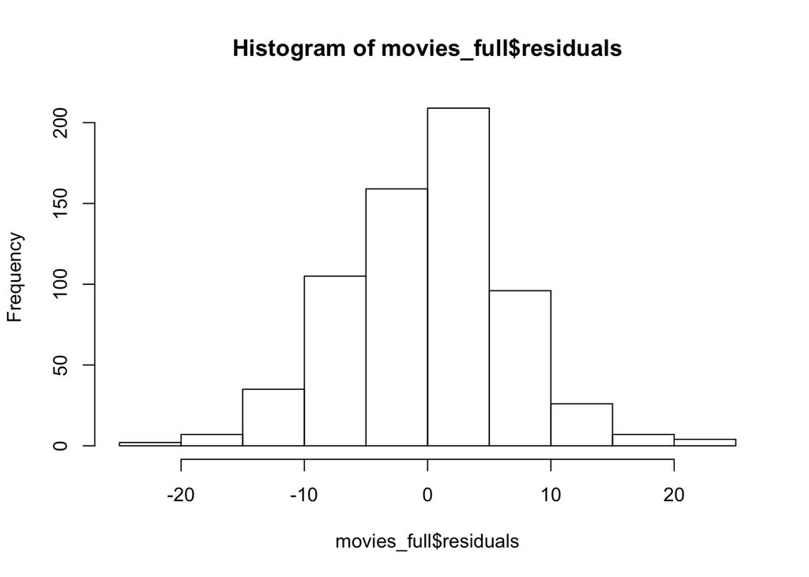

```r
hist(movies_full$residuals)
```

Besides, we can also use a normal probability plot of the residuals for checking.

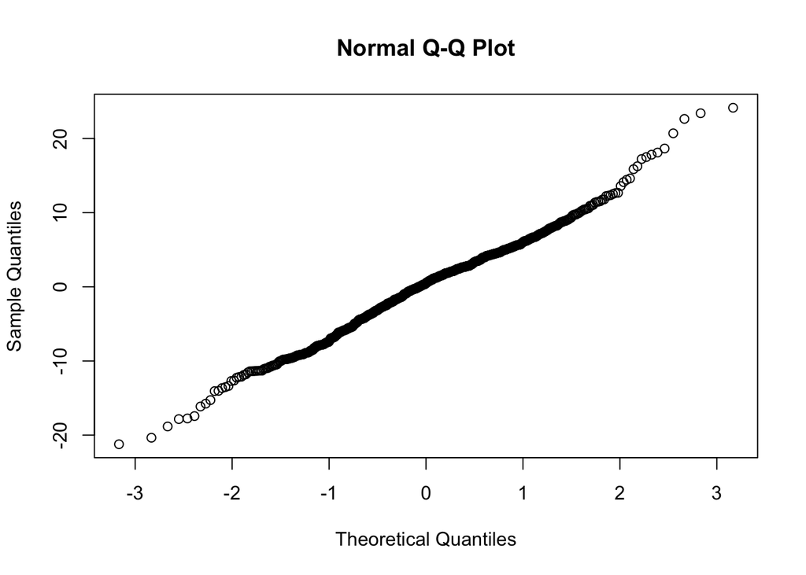

```r
qqnorm(movies_full$residuals)
```

We saw a nearly normal distribution of residuals centered at 0 here.

**Constant Variability of Residuals**: We will use residuals plots to check.

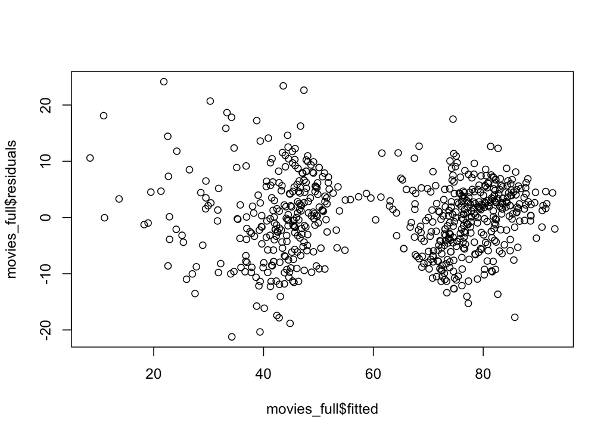

```r
plot(movies_full$residuals ~ movies_full$fitted)
```

**Independent Residuals**: residuals plots are used to check.

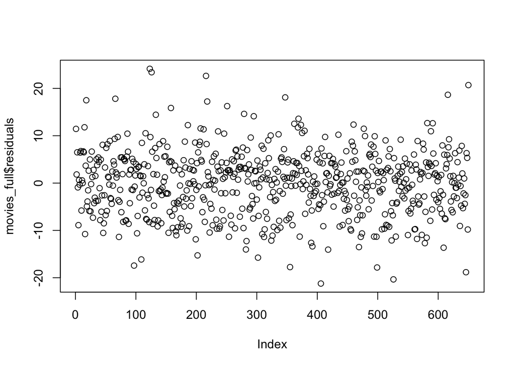

```r
plot(movies_full$residuals)
```

Now, we can safely present this model as our final model since it passed the diagnostics.

## Part 6: Conclusion

However, this project also has room for improvements since the caculations in building the model took a long time to repeat as we drop one variable each time for seeking a best model. We may hope to address this problem in the future study.